# Lab 8 - K Means Clustering

## Name and Id: Roy Paz

```python
! mkdir ~/.kaggle
! cp kaggle.json ~/.kaggle/
! chmod 600 ~/.kaggle/kaggle.json
! kaggle datasets download rinichristy/covid19-coronavirus-pandemic
! unzip /content/covid19-coronavirus-pandemic.zip
```

```
Downloading covid19-coronavirus-pandemic.zip to /content
  0% 0.00/8.60k [00:00<?, ?B/s]
100% 8.60k/8.60k [00:00<00:00, 17.0MB/s]
Archive:  /content/covid19-coronavirus-pandemic.zip
  inflating: COVID-19 Coronavirus.csv
```

## About the data:

this dataset contains COVID-19 information about 225 countries. our aim is to cluster those countries by severity of the pandemic.

features:

- country - the name of the country, we use it a index.
- other names - other name of the country
- ISO 3166-1 alpha-3 CODE - three-letter country codes defined in ISO 3166-1
- Population - number of people in the country
- Continent - the continent of the country
- Total Cases
- Total Deaths
- Tot Cases//1M pop - Total Covid 19 cases per million population
- Tot Deaths/1M pop - Total deaths related to Covid 19 cases per million population
- Death percentage - Total Death per Total Covid 19 cases reported

## Task 1:

Load the file 'COVID-19 Coronavirus.csv'

Perform basic feature analysis (statistics, histograms)

Drop irelevant features and encode categorical features

```python
import pandas as pd

data = pd.read_csv('/content/COVID-19 Coronavirus.csv', index_col='Country')
data
```

| Country | Other names | ISO 3166-1 alpha-3 CODE | Population | Continent | Total Cases | Total Deaths | Tot Cases//1M pop | Tot Deaths/1M pop | Death percentage |
| --- | --- | --- | --- | --- | --- | --- | --- | --- | --- |
| Afghanistan | Afghanistan | AFG | 40462186 | Asia | 177827 | 7671 | 4395 | 190 | 4.313743 |
| Albania | Albania | ALB | 2872296 | Europe | 273870 | 3492 | 95349 | 1216 | 1.275058 |
| Algeria | Algeria | DZA | 45236699 | Africa | 265691 | 6874 | 5873 | 152 | 2.587216 |
| Andorra | Andorra | AND | 77481 | Europe | 40024 | 153 | 516565 | 1975 | 0.382271 |
| Angola | Angola | AGO | 34654212 | Africa | 99194 | 1900 | 2862 | 55 | 1.915438 |
| ... | ... | ... | ... | ... | ... | ... | ... | ... | ... |
| Wallis and Futuna | Wallis and Futuna Islands | WLF | 10894 | Oceania | 454 | 7 | 41674 | 643 | 1.541850 |
| Western Sahara | Western Sahara | ESHÂ | 623031 | Africa | 10 | 1 | 16 | 2 | 10.000000 |
| Yemen | Yemen | YEM | 30975258 | Asia | 11806 | 2143 | 381 | 69 | 18.151787 |
| Zambia | Zambia | ZMB | 19284482 | Africa | 317076 | 3967 | 16442 | 206 | 1.251120 |
| Zimbabwe | Zimbabwe | ZWE | 15241601 | Africa | 246525 | 5446 | 16174 | 357 | 2.209107 |

225 rows × 9 columns

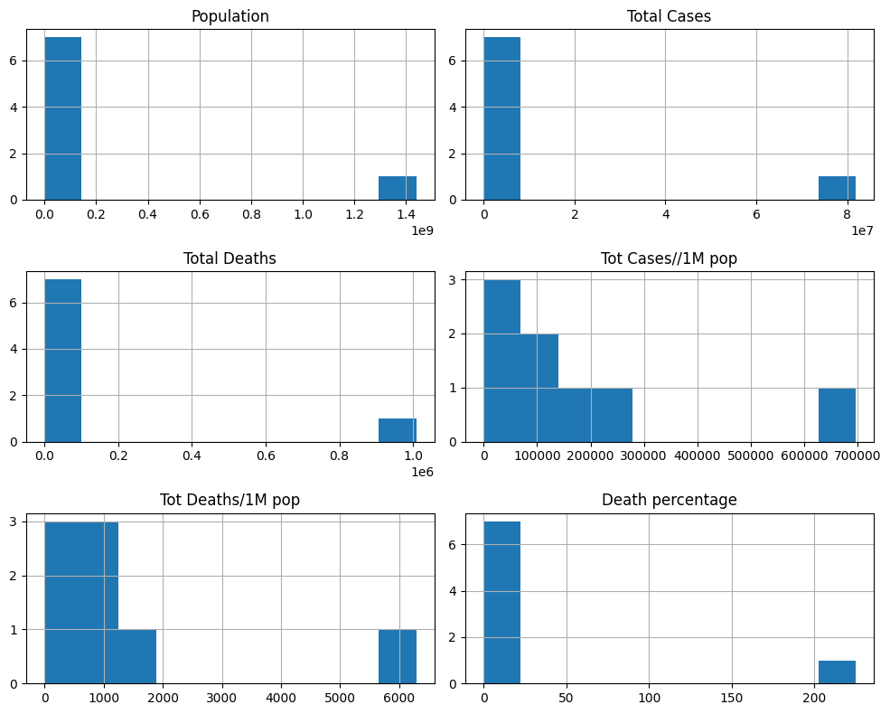

```python
import matplotlib.pyplot as plt
from mpl_toolkits.mplot3d import Axes3D
from sklearn.decomposition import PCA

statistics = data.describe()
statistics.hist(figsize=(10, 8))
plt.tight_layout()
plt.show()

data.drop(['Other names', 'ISO 3166-1 alpha-3 CODE'], axis=1, inplace=True)
data = pd.get_dummies(data, columns=['Continent'])
```

## Task 2:

Use sklearn.decomposition.PCA to reduce dimentions to 3 and scatter plot the data once as 2D plot and once as 3D plot

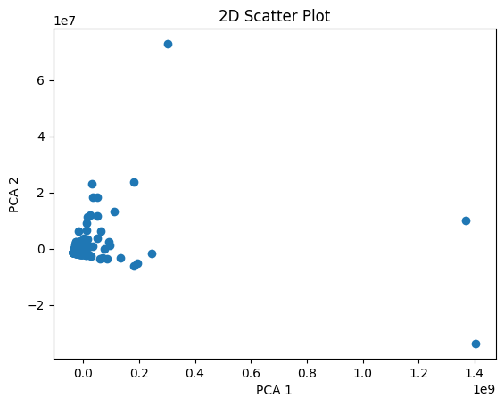

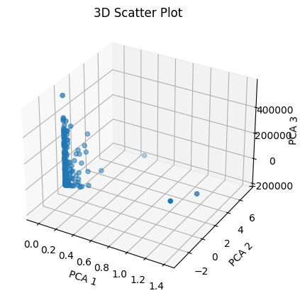

```python
pca = PCA(n_components=3)
pca = pca.fit_transform(data)
plt.scatter(pca[:, 0], pca[:, 1])
plt.xlabel('PCA 1')
plt.ylabel('PCA 2')
plt.title('2D Scatter Plot')
plt.show()

print()
fig = plt.figure()
ax = fig.add_subplot(111, projection='3d')
ax.scatter(pca[:, 0], pca[:, 1], pca[:, 2])
ax.set_xlabel('PCA 1')
ax.set_ylabel('PCA 2')
ax.set_zlabel('PCA 3')
ax.set_title('3D Scatter Plot')
plt.show()
```

## Task 3:

Select the best K using elbow method - train KMeans model with different k values and for each of them save the attribute inertia which represents the sum of squared distances of samples to their closest cluster center, weighted by the sample weights if provided. plot your results. x axis is the K value and y axis is the inertia.

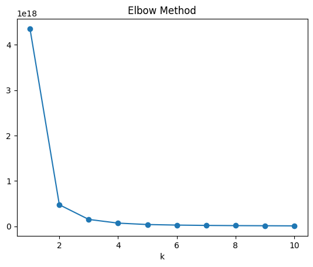

```python
from sklearn.cluster import KMeans
import warnings

warnings.filterwarnings("ignore", category=FutureWarning)
k_list = []
vals = range(1, 11)
for k in vals:
    algorithm = KMeans(n_clusters=k)
    algorithm.fit(data)
    k_list.append(algorithm.inertia_)
plt.plot(range(1, 11) , k_list, marker='o')
plt.xlabel('k')
plt.title('Elbow Method')
plt.show()
```

## Task 4:

Select the best K received by the elbow method - we are looking for poins where there is significant change in the inertia values.

Scatter plot the clusters using color to indecate different clusters and show each cluster's center

[figure not shown]

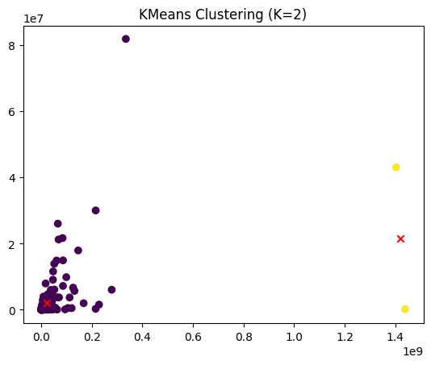

```python
kmeans = KMeans(n_clusters=2)
kmeans.fit(data)
plt.scatter(data.iloc[:, 0], data.iloc[:, 1], c=kmeans.labels_, cmap='viridis')
plt.scatter(kmeans.cluster_centers_[:, 0], kmeans.cluster_centers_[:, 1], c='red', marker='x')
plt.title(f'KMeans Clustering (K={2})')
plt.show()
```

## Task 5:

Convert the notebook into html:

1. Download the notebook by clicking the File tab
2. Upload it to this environment
3. Run the command:

```python
%%shell
jupyter nbconvert --to html Lab8.ipynb
```

```
[NbConvertApp] Converting notebook Lab8.ipynb to html
[NbConvertApp] Writing 845275 bytes to Lab8.html
```